# Easy_Visa

```python
# Install the library (the '!' allows you to run terminal commands inside the notebook)
!pip install imbalanced-learn
```

```python
!brew install libomp
```

```python
import xgboost
# ... other imports ...
```

```python
import pandas as pd
import numpy as np
import matplotlib.pyplot as plt
import seaborn as sns

# The libraries we just fixed
import xgboost as xgb
from xgboost import XGBClassifier
from imblearn.over_sampling import SMOTE

# Evaluation tools
from sklearn.model_selection import train_test_split
from sklearn.metrics import classification_report, confusion_matrix
```

```python
# 1. Imports (Already Done)
import pandas as pd
import numpy as np

# 2. Display Settings (Run these now)
pd.set_option("display.max_columns", None)
pd.set_option("display.max_rows", 100)
```

```python
# This creates the 'visa' variable.
# Ensure the file name matches exactly (case-sensitive)
visa = pd.read_csv("//Users/clementquagraine/Downloads/EasyVisa.csv")
```

```python
data = visa.copy()
```

```python
data.head()
```

|  | case_id | continent | education_of_employee | has_job_experience | requires_job_training | no_of_employees | yr_of_estab | region_of_employment | prevailing_wage | unit_of_wage | full_time_position | case_status |
| --- | --- | --- | --- | --- | --- | --- | --- | --- | --- | --- | --- | --- |
| 0 | EZYV01 | Asia | High School | N | N | 14513 | 2007 | West | 592.2029 | Hour | Y | Denied |
| 1 | EZYV02 | Asia | Master's | Y | N | 2412 | 2002 | Northeast | 83425.6500 | Year | Y | Certified |
| 2 | EZYV03 | Asia | Bachelor's | N | Y | 44444 | 2008 | West | 122996.8600 | Year | Y | Denied |
| 3 | EZYV04 | Asia | Bachelor's | N | N | 98 | 1897 | West | 83434.0300 | Year | Y | Denied |
| 4 | EZYV05 | Africa | Master's | Y | N | 1082 | 2005 | South | 149907.3900 | Year | Y | Certified |

```python
data.tail()
```

|  | case_id | continent | education_of_employee | has_job_experience | requires_job_training | no_of_employees | yr_of_estab | region_of_employment | prevailing_wage | unit_of_wage | full_time_position | case_status |
| --- | --- | --- | --- | --- | --- | --- | --- | --- | --- | --- | --- | --- |
| 25475 | EZYV25476 | Asia | Bachelor's | Y | Y | 2601 | 2008 | South | 77092.57 | Year | Y | Certified |
| 25476 | EZYV25477 | Asia | High School | Y | N | 3274 | 2006 | Northeast | 279174.79 | Year | Y | Certified |
| 25477 | EZYV25478 | Asia | Master's | Y | N | 1121 | 1910 | South | 146298.85 | Year | N | Certified |
| 25478 | EZYV25479 | Asia | Master's | Y | Y | 1918 | 1887 | West | 86154.77 | Year | Y | Certified |
| 25479 | EZYV25480 | Asia | Bachelor's | Y | N | 3195 | 1960 | Midwest | 70876.91 | Year | Y | Certified |

## Understanding the shape of the dataset

```python
data.shape
```

```
(25480, 12)
```

##### The dataset contains 25,480 rows and 12 columns.

## Checking the data types of the columns for the dataset

```python
data.info()
```

```
<class 'pandas.core.frame.DataFrame'>
RangeIndex: 25480 entries, 0 to 25479
Data columns (total 12 columns):
 #   Column                 Non-Null Count  Dtype
---  ------                 --------------  -----
 0   case_id                25480 non-null  object
 1   continent              25480 non-null  object
 2   education_of_employee  25480 non-null  object
 3   has_job_experience     25480 non-null  object
 4   requires_job_training  25480 non-null  object
 5   no_of_employees        25480 non-null  int64
 6   yr_of_estab            25480 non-null  int64
 7   region_of_employment   25480 non-null  object
 8   prevailing_wage        25480 non-null  float64
 9   unit_of_wage           25480 non-null  object
 10  full_time_position     25480 non-null  object
 11  case_status            25480 non-null  object
dtypes: float64(1), int64(2), object(9)
memory usage: 2.3+ MB
```

#### Data Types:

##### For the numerical columns: no_of_employees, yr_of_estab are int64 (integers), while prevailing_wage is float64 (floating-point numbers).

##### The remaining 9 columns are categorical: That is case_id, continent, education_of_employee, has_job_experience, requires_job_training, region_of_employment, unit_of_wage, full_time_position, case_status (of which they are object type).

## Checking for duplicate values

```python
data.duplicated().sum()
```

```
np.int64(0)
```

##### There are no duplicate rows in your dataset. This is a positive finding as it means all records are unique, which is good for data quality.

### Checking for missing values

```python
data.isnull().sum()
```

```
case_id                  0
continent                0
education_of_employee    0
has_job_experience       0
requires_job_training    0
no_of_employees          0
yr_of_estab              0
region_of_employment     0
prevailing_wage          0
unit_of_wage             0
full_time_position       0
case_status              0
dtype: int64
```

##### all columns have 25480 non-null entries. This indicates that there are no missing values in this dataset.

## Exploratory Data Analysis (EDA)

### Let's check the statistical summary of the data

```python
data.describe().T
```

|  | count | mean | std | min | 25% | 50% | 75% | max |
| --- | --- | --- | --- | --- | --- | --- | --- | --- |
| no_of_employees | 25480.0 | 5667.043210 | 22877.928848 | -26.0000 | 1022.00 | 2109.00 | 3504.0000 | 602069.00 |
| yr_of_estab | 25480.0 | 1979.409929 | 42.366929 | 1800.0000 | 1976.00 | 1997.00 | 2005.0000 | 2016.00 |
| prevailing_wage | 25480.0 | 74455.814592 | 52815.942327 | 2.1367 | 34015.48 | 70308.21 | 107735.5125 | 319210.27 |

#### From the above, we can realise that

##### For no_of_employees: The minimum value is -26, which is impossible for a count of employees, indicating a data entry error or anomaly that will need to be addressed (e.g., through correction, removal, or imputation). The mean (5,667) is also significantly higher than the median (2,109), and the maximum value (602,069) is exceptionally large. This suggests a highly right-skewed distribution, meaning a small number of companies have extraordinarily high employee counts. The high standard deviation (22,877) further confirms a wide spread in the data.

##### For yr_of_estab: The years range from 1800 to 2016, which is a reasonable and expected range for company establishment dates. The mean (approximately 1,979) is slightly lower than the median (aproximatley 1,997), suggesting a mild left skew.

##### For prevailing_wage: Wages vary widely, from a minimum of ~2.14 to a maximum of ~319,210. This broad range is likely attributable to differences in job roles, industries, experience levels, or geographic regions.

## Fixing the negative values in the number of employees columns

```python
data.loc[data["no_of_employees"] < 0].shape
```

```
(33, 12)
```

## Converting negative numbers to positive numbers using the absolute value function.

```python
# taking the absolute values for number of employees
data["no_of_employees"] = abs(data["no_of_employees"])
```

## Let's check the count of each unique category in each of the categorical variables

```python
# Making a list of all categorical variables
cat_col = list(data.select_dtypes("object").columns)

# Printing number of count of each unique value in each column
for column in cat_col:
    print(data[column].value_counts())
    print("-" * 50)
```

```
case_id
EZYV01       1
EZYV16995    1
EZYV16993    1
EZYV16992    1
EZYV16991    1
            ..
EZYV8492     1
EZYV8491     1
EZYV8490     1
EZYV8489     1
EZYV25480    1
Name: count, Length: 25480, dtype: int64
--------------------------------------------------
continent
Asia             16861
Europe            3732
North America     3292
South America      852
Africa             551
Oceania            192
Name: count, dtype: int64
--------------------------------------------------
education_of_employee
Bachelor's     10234
Master's        9634
High School     3420
Doctorate       2192
Name: count, dtype: int64
--------------------------------------------------
has_job_experience
Y    14802
N    10678
Name: count, dtype: int64
--------------------------------------------------
requires_job_training
N    22525
Y     2955
Name: count, dtype: int64
--------------------------------------------------
```

[output cut: 10 more lines]

```
Hour      2157
Week       272
Month       89
Name: count, dtype: int64
--------------------------------------------------
full_time_position
Y    22773
N     2707
Name: count, dtype: int64
--------------------------------------------------
case_status
Certified    17018
Denied        8462
Name: count, dtype: int64
--------------------------------------------------
```

##### From the value_counts() output, the case_status column is clearly imbalanced, with Certified cases being significantly more frequent than Denied cases. This is an important observation, particularly when building predictive models, as imbalanced datasets can cause models to perform poorly on the minority class — in this case, Denied. Further analysis will be conducted on this distribution, and appropriate techniques to address the imbalance (such as oversampling, undersampling, or class weighting) will be considered during model training.

```python
# checking the number of unique values
data["case_id"].nunique()
```

```
25480
```

##### The value 25,480 confirms that case_id serves as a unique identifier for each record in the dataset. Since it uniquely identifies each row but carries no predictive information, we can drop from the dataset before model training

```python
data.drop(["case_id"], axis=1, inplace=True)
```

## Univariate Analysis

### Functions required for EDA

```python
# function to create labeled barplots


def labeled_barplot(data, feature, perc=False, n=None):
    """
    Barplot with percentage at the top

    data: dataframe
    feature: dataframe column
    perc: whether to display percentages instead of count (default is False)
    n: displays the top n category levels (default is None, i.e., display all levels)
    """

    total = len(data[feature])  # length of the column
    count = data[feature].nunique()
    if n is None:
        plt.figure(figsize=(count + 1, 5))
    else:
        plt.figure(figsize=(n + 1, 5))

    plt.xticks(rotation=90, fontsize=15)
    ax = sns.countplot(
        data=data,
        x=feature,
        palette="Paired",
        order=data[feature].value_counts().index[:n].sort_values(),
    )

    for p in ax.patches:
        if perc == True:
            label = "{:.1f}%".format(
                100 * p.get_height() / total
            )  # percentage of each class of the category
        else:
            label = p.get_height()  # count of each level of the category

        x = p.get_x() + p.get_width() / 2  # width of the plot
        y = p.get_height()  # height of the plot

        ax.annotate(
            label,
            (x, y),
            ha="center",
            va="center",
            size=12,
            xytext=(0, 5),
            textcoords="offset points",
        )  # annotate the percentage

    plt.show()  # show the plot
```

```python
def histogram_boxplot(data, feature, figsize=(15, 10), kde=False, bins=None):
    """
    Boxplot and histogram combined

    data: dataframe
    feature: dataframe column
    figsize: size of figure (default (15,10))
    kde: whether to show the density curve (default False)
    bins: number of bins for histogram (default None)
    """
    f2, (ax_box2, ax_hist2) = plt.subplots(
        nrows=2,  # Number of rows of the subplot grid= 2
        sharex=True,  # x-axis will be shared among all subplots
        gridspec_kw={"height_ratios": (0.25, 0.75)},
        figsize=figsize,
    )  # creating the 2 subplots
    sns.boxplot(
        data=data, x=feature, ax=ax_box2, showmeans=True, color="violet"
    )  # boxplot will be created and a triangle will indicate the mean value of the column
    sns.histplot(
        data=data, x=feature, kde=kde, ax=ax_hist2, bins=bins
    ) if bins else sns.histplot(
        data=data, x=feature, kde=kde, ax=ax_hist2
    )  # For histogram
    ax_hist2.axvline(
        data[feature].mean(), color="green", linestyle="--"
    )  # Add mean to the histogram
    ax_hist2.axvline(
        data[feature].median(), color="black", linestyle="-"
    )  # Add median to the histogram
```

### Observations on the education of employees

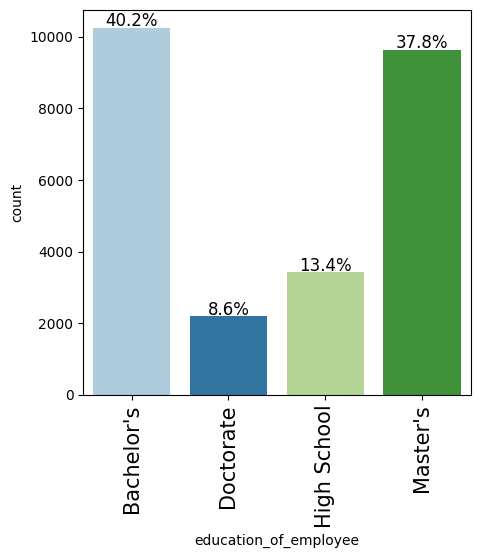

```python
labeled_barplot(data, "education_of_employee", perc=True)
```

#### Based on the bar plot for education_of_employee, the following distribution of education levels can be observed among visa applicants:

##### Bachelor's Degree: The most common education level, accounting for the largest proportion of applicants.

##### Master's Degree: The second most frequent, with a large number of applicants also holding a Master's degree.

##### High School: A smaller proportion of applicants hold only a high school education.

##### Doctorate: The least represented group, with the lowest percentage of applicants possessing a Doctorate degree.

##### This distribution suggests that the substantial majority of visa applicants in this dataset hold higher education qualifications — specifically a Bachelor's or Master's degree — which is often a formal requirement or a strong advantage for employment-based visas. The relatively lower representation of High School and Doctoral holders may reflect the specific academic requirements tied to the types of jobs or visa categories being applied for.

## Observations on region of employment

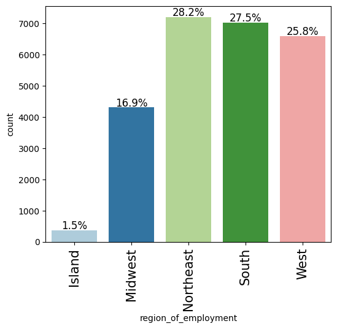

```python
labeled_barplot(data, "region_of_employment", perc=True)
```

#### Based on the distribution of region_of_employment, the following observations can be made:

##### Dominant Regions: The Northeast (28.2%), South (27.5%), and West (25.8%) are the three dominant employment regions, collectively accounting for over 81% of all visa cases. This strong concentration suggests that these areas serve as major employment hubs for the types of roles attracting visa applicants, indicating either higher demand, greater availability of opportunities, or a higher prevalence of visa-sponsoring employers in these regions.

##### Midwest: With a moderate representation of 16.9%, the Midwest accounts for a meaningful share of employment cases — less than the top three regions but still substantial enough to be noteworthy.

##### Island: The Island region has a notably low representation of just 1.5%, suggesting limited opportunities or a comparatively small market for visa-sponsored jobs in those areas.

## Observations on job experience

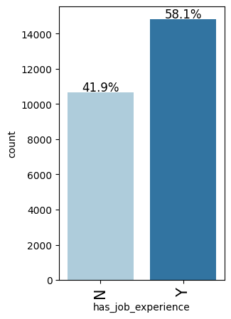

```python
labeled_barplot(data, "has_job_experience", perc=True)
```

#### Based on the bar plot for has_job_experience, the following observations can be made:

##### With Job Experience (Y): A significant majority of visa applicants have prior job experience. This suggests that job experience is either a prerequisite for the types of visas being applied for or a strong contributing factor to successful applications.

##### Without Job Experience (N): A smaller proportion of applicants have no prior job experience. These individuals may include recent graduates, applicants pursuing roles that do not strictly require prior experience, or those applying under different visa categories.

## Observations on no_of_employees

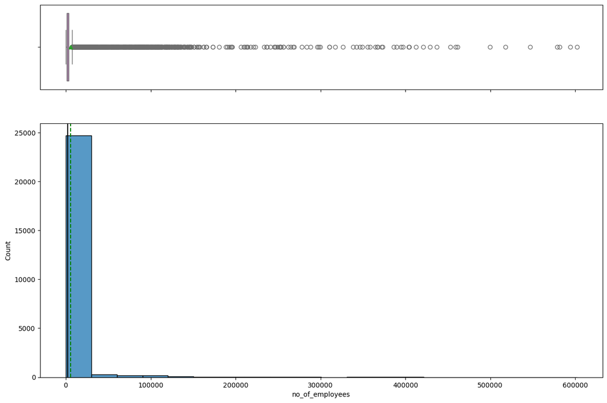

```python
histogram_boxplot(data, 'no_of_employees', bins = 20)
```

#### Based on the combined histogram and boxplot for no_of_employees, the following observations can be made:

##### Extreme Right Skewness: The histogram is heavily right-skewed, with a large number of companies having a relatively small number of employees. The frequency drops sharply as the employee count increases, indicating that very large companies are rare in this dataset.

##### Presence of Outliers: The boxplot clearly reveals numerous outliers on the upper end of the distribution. These outliers represent a small number of companies with significantly larger employee counts compared to the majority, confirming the presence of a few exceptionally large organizations in the dataset.

##### Mean vs. Median: The mean (green dashed line) is considerably greater than the median (black solid line), which is a strong indicator of the right-skewed distribution and reflects the disproportionate influence of high-value outliers on the mean.

##### This distribution implies that while the majority of visa applications are associated with smaller companies, a small number of very large organizations are also represented. The pronounced skewness suggests that preprocessing steps such as log transformation or the use of robust statistical methods may be necessary during model training to prevent the model from being unduly influenced by these large employer outliers.

## Observations on yr_of_estab

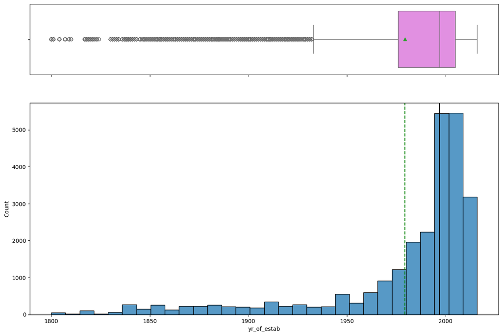

```python
histogram_boxplot(data, 'yr_of_estab', bins=30)
```

#### Based on the combined histogram and boxplot for yr_of_estab, the following observations can be made:

##### Wide Range: The years of establishment span a broad period from 1800 to 2016, indicating that the dataset includes companies of varying ages — from long-standing legacy institutions to recently founded organizations.

##### Median (1997): Half of the companies in the dataset were established after 1997, reflecting a strong presence of relatively modern organizations.

##### Mean (~1979): The mean is pulled lower than the median by the presence of older companies, further confirming the left-skewed nature of the distribution.

##### Concentration in Recent Decades: The histogram shows a notably higher frequency of companies established from the late 20th century onwards, with a pronounced peak between the 1970s and 2000s. This suggests a significant surge in company formation during this period.

##### Left Skewness: The distribution is slightly left-skewed, indicating that the majority of companies were established more recently, with progressively fewer companies the further back in history one looks. This is reflected by the median (black line) sitting to the right of the mean (green dashed line), with the mean being pulled leftward by very old establishments.

##### Outliers: The boxplot reveals several outliers on the left side of the distribution, representing very old legacy institutions — some dating as far back as the 1800s — that remain active and continue to sponsor visas today.

##### Overall, the data reflects a dynamic organizational landscape dominated by modern companies, while still including a notable number of long-standing establishments. The bulk of the visa-sponsoring population consists of companies that are less than 50 years old, suggesting that newer organizations are the primary drivers of employment-based visa applications.

## Observations on full_time_position

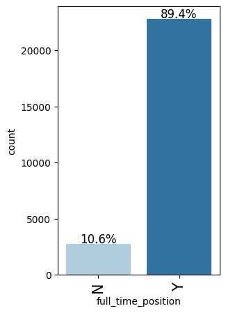

```python
labeled_barplot(data, "full_time_position", perc=True)
```

#### Based on the bar plot for full_time_position, the following observations can be made:

##### Full-Time (Y): The vast majority of visa applicants — 89.4% — are applying for full-time positions, reflecting that full-time employment is either a common requirement or a strong preference associated with employment-based visa applications.

##### Non-Full-Time (N): Only a small fraction — 10.6% — of applications are associated with part-time or non-full-time roles. This smaller proportion may represent specific job types, niche industries, or unique employment arrangements that still qualify for visa sponsorship.

##### Overall, the strong dominance of full-time positions in this dataset suggests that employment-based visa programs are predominantly utilized by applicants seeking stable, full-time employment. The relatively minor share of non-full-time roles, while small, is still worth accounting for during model training to ensure the minority group is adequately represented.

## Observations on case status

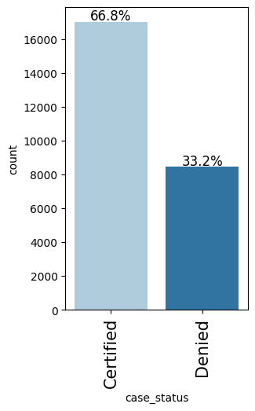

```python
labeled_barplot(data, "case_status", perc=True)
```

#### Based on the analysis of the case_status column, the following observations can be made:

##### Certified: Approximately 66.8% of all visa applications in the dataset have been certified, making it the dominant class.

##### Denied: The remaining 33.2% of applications were denied, representing the minority class.

##### The dataset is therefore imbalanced, with Certified cases occurring at roughly twice the rate of Denied cases. This imbalance is a critical observation, as it can significantly impact the performance of machine learning models — particularly in their ability to correctly predict the minority class (Denied). If left unaddressed, models may develop a bias toward the majority class, leading to poor recall on Denied cases. Appropriate strategies such as oversampling (e.g., SMOTE), undersampling, or class weighting will need to be considered and applied during model training to ensure fair and reliable predictions across both classes.

# Bivariate Analysis

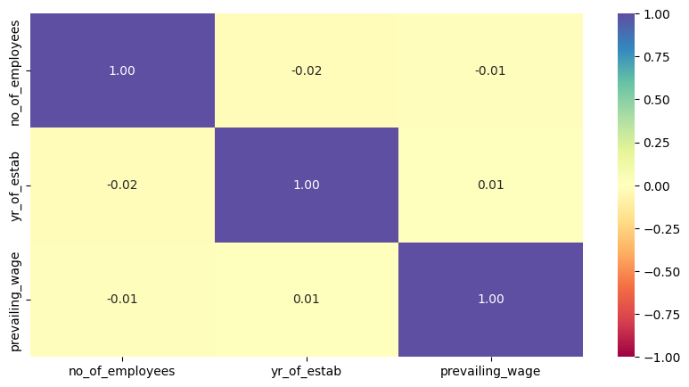

```python
cols_list = data.select_dtypes(include=np.number).columns.tolist()

plt.figure(figsize=(10, 5))
sns.heatmap(
    data[cols_list].corr(), annot=True, vmin=-1, vmax=1, fmt=".2f", cmap="Spectral"
)
plt.show()
```

#### The following observations can be made on the numerical features in this dataset operate on vastly different scales — years of establishment, number of employees, and prevailing wages:

##### Weak Linear Correlations: The majority of correlation coefficients are close to 0, indicating no strong linear relationship between no_of_employees, yr_of_estab, and prevailing_wage. This suggests that these features vary largely independently of one another.

##### Low Multicollinearity: Given that all correlations are low (typically < 0.3), there is little concern about multicollinearity — a condition where one independent variable is a near-perfect linear combination of another. This is a favorable outcome, particularly for models such as Logistic Regression, which assumes that the independent variables are not highly correlated with one another.

## Creating functions to help with further analysis.

```python
### function to plot distributions wrt target


def distribution_plot_wrt_target(data, predictor, target):

    fig, axs = plt.subplots(2, 2, figsize=(12, 10))

    target_uniq = data[target].unique()

    axs[0, 0].set_title("Distribution of target for target=" + str(target_uniq[0]))
    sns.histplot(
        data=data[data[target] == target_uniq[0]],
        x=predictor,
        kde=True,
        ax=axs[0, 0],
        color="teal",
        stat="density",
    )

    axs[0, 1].set_title("Distribution of target for target=" + str(target_uniq[1]))
    sns.histplot(
        data=data[data[target] == target_uniq[1]],
        x=predictor,
        kde=True,
        ax=axs[0, 1],
        color="orange",
        stat="density",
    )

    axs[1, 0].set_title("Boxplot w.r.t target")
    sns.boxplot(data=data, x=target, y=predictor, ax=axs[1, 0], palette="gist_rainbow")

    axs[1, 1].set_title("Boxplot (without outliers) w.r.t target")
    sns.boxplot(
        data=data,
        x=target,
        y=predictor,
        ax=axs[1, 1],
        showfliers=False,
        palette="gist_rainbow",
    )

    plt.tight_layout()
    plt.show()
```

```python
def stacked_barplot(data, predictor, target):
    """
    Print the category counts and plot a stacked bar chart

    data: dataframe
    predictor: independent variable
    target: target variable
    """
    count = data[predictor].nunique()
    sorter = data[target].value_counts().index[-1]
    tab1 = pd.crosstab(data[predictor], data[target], margins=True).sort_values(
        by=sorter, ascending=False
    )
    print(tab1)
    print("-" * 120)
    tab = pd.crosstab(data[predictor], data[target], normalize="index").sort_values(
        by=sorter, ascending=False
    )
    tab.plot(kind="bar", stacked=True, figsize=(count + 5, 5))
    plt.legend(
        loc="lower left", frameon=False,
    )
    plt.legend(loc="upper left", bbox_to_anchor=(1, 1))
    plt.show()
```

## Let's find out if education has any impact on visa certification

```
case_status            Certified  Denied    All
education_of_employee
All                        17018    8462  25480
Bachelor's                  6367    3867  10234
High School                 1164    2256   3420
Master's                    7575    2059   9634
Doctorate                   1912     280   2192
------------------------------------------------------------------------------------------------------------------------
```

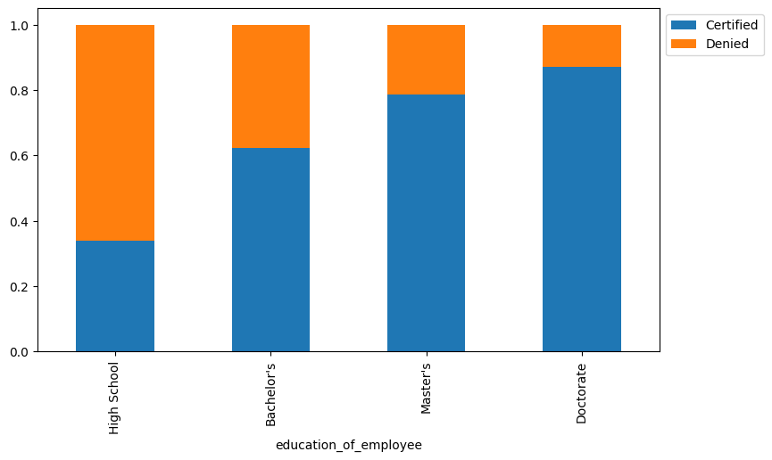

```python
stacked_barplot(data, "education_of_employee", "case_status")
```

#### Based on the stacked bar plot of education_of_employee against case_status, the following observations can be made:

##### Higher Education, Higher Certification Rate: Applicants holding Master's and Doctorate degrees demonstrate significantly higher certification rates compared to those with Bachelor's or High School education. Doctorate holders record the highest success rate at over 85% (1,912 Certified vs. 280 Denied), while Master's degree holders also perform strongly (7,575 Certified vs. 2,059 Denied). This likely reflects the specialized nature of the roles associated with advanced degrees, making it considerably easier for the Department of Labor to justify that no suitably qualified local worker is available to fill the position.

##### Bachelor's Degree: Although Bachelor's degree holders represent the largest group of applicants, their certification rate of approximately 62% falls slightly below the overall dataset average of 66.8%, with a notably higher proportion of denials compared to Master's and Doctorate holders (6,367 Certified vs. 3,867 Denied). This suggests that a Bachelor's degree may serve as the minimum educational threshold for many visa applications, but is not in itself a strong guarantee of certification success.

##### High School Education: Applicants with only a High School education have the lowest certification rate and the highest denial rate proportionally, with just 34% of applications being certified (1,164 Certified vs. 2,256 Denied). This indicates that a high school education alone is generally insufficient for visa certification in this dataset, reflecting a strong preference for higher academic qualifications. The roles typically associated with this education level are often considered non-specialized, making certification considerably more difficult to obtain and rendering a high school qualification a significant risk factor for denial.

##### Inference: There is a clear positive relationship between education level and the likelihood of visa certification. Higher educational qualifications — particularly Master's and Doctorate degrees — represent a significant advantage in the visa application process, while lower qualifications, especially at the High School level, are strongly associated with higher denial rates.

## Lets' similarly check for the continents and find out how the visa status vary across different continents.

```
case_status    Certified  Denied    All
continent
All                17018    8462  25480
Asia               11012    5849  16861
North America       2037    1255   3292
Europe              2957     775   3732
South America        493     359    852
Africa               397     154    551
Oceania              122      70    192
------------------------------------------------------------------------------------------------------------------------
```

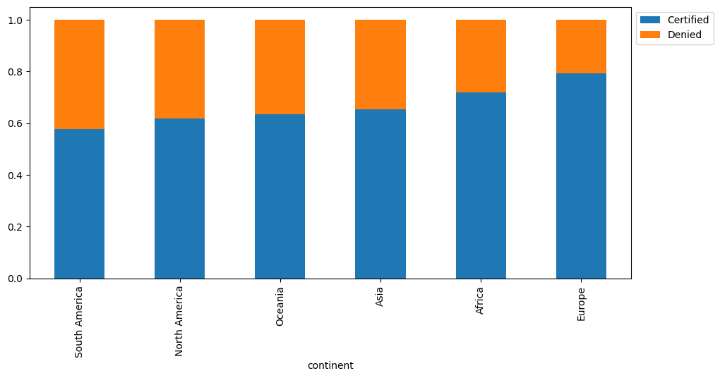

```python
stacked_barplot(data, "continent", "case_status")
```

#### Based on the stacked bar plot of continent against case_status, the following observations can be made:

##### Asia — Highest Application Volume (~65% certification rate): Asia dominates visa applications by a significant margin, recording the highest total of 16,861 applications (11,012 Certified vs. 5,849 Denied). Despite this large volume, Asia's certification rate of approximately 65% is close to the overall dataset average of 66.8%, suggesting that the sheer volume of applications does not translate into a disproportionately high or low success rate.

##### Europe — Highest Certification Rate (~79%): Europe records the strongest certification rate among all continents, with 2,957 out of 3,732 applications certified and only 775 denied. This notably high success rate likely reflects the prevalence of highly specialized roles among European applicants, as well as established trade and employment ties between European countries and the visa-sponsoring market.

##### North America — Moderate Performance (~61%): North America accounts for 3,292 applications (2,037 Certified vs. 1,255 Denied), with a certification rate slightly below the overall dataset average. This moderate performance may be attributable to a higher proportion of diverse, entry-level roles that are less likely to meet the specialized criteria required for certification.

##### Africa — Above Average Certification Rate (~71%): Africa records 397 Certified vs. 154 Denied applications, yielding a certification rate of approximately 71% — notably above the overall baseline of 66.8%. Despite its comparatively lower application volume, Africa's strong certification rate suggests that its applicants tend to be well-qualified relative to the roles they are applying for.

##### South America — Lowest Certification Rate (~58%): South America has the lowest certification rate among all continents, with 493 Certified vs. 359 Denied applications. This below-average performance suggests that South American applicants may face greater challenges in meeting certification requirements, possibly due to the nature of the roles applied for or other qualifying factors.

##### Oceania — Smallest Application Volume (~62%): Oceania contributes the fewest applications in the dataset, with only 192 total (122 Certified vs. 70 Denied) and a moderate certification rate of approximately 62%. The small sample size means that conclusions drawn from this group should be interpreted with caution.

##### Inference: While Asia contributes the largest share of visa applications, Europe stands out with the highest certification rate, suggesting a strong alignment between European applicants' qualifications and the requirements of the roles they apply for. The considerable variation in certification rates across continents points to underlying differences in applicant qualifications, the nature of roles being applied for, and potentially region-specific visa policies. These continental differences may prove to be a meaningful predictive feature during model training.

## Let's see if having work experience has any influence over visa certification

```
case_status         Certified  Denied    All
has_job_experience
All                     17018    8462  25480
N                        5994    4684  10678
Y                       11024    3778  14802
------------------------------------------------------------------------------------------------------------------------
```

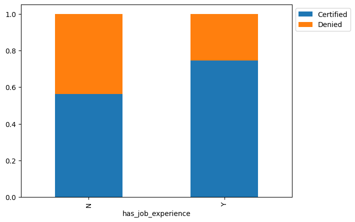

```python
stacked_barplot(data, "has_job_experience", "case_status")
```

#### Based on the stacked bar plot of has_job_experience against case_status, the following observations can be made:

##### Higher Certification Rate with Job Experience (Y): Applicants with prior job experience demonstrate a significantly higher certification rate compared to those without. Approximately 74.5% of experienced applicants were certified (11,024 out of 14,802), reflecting a strong alignment between prior work experience and the qualifications required for visa approval. with a denial rate of approximately 25.5% (3,778 out of 14802)

##### Lower Certification Rate without Job Experience (N): In contrast, applicants without job experience recorded a notably lower certification rate of approximately 56.1% (5,994 out of 10,678), accompanied by a substantially higher denial rate of 43.9% (4,684 out of 10,678). This suggests that the absence of prior work experience is a considerable disadvantage in the visa certification process, with nearly half of such applications being denied.

##### Inference: Prior job experience emerges as a strong positive predictor of visa certification. The considerable gap in certification rates between experienced (74.5%) and inexperienced (56.1%) applicants — a difference of approximately 18.4 percentage points — indicates that visa adjudicators and employers place significant weight on prior work experience when evaluating applications. As such, has_job_experience is likely to be an important and informative feature during model training.

## Checking if the prevailing wage is similar across all the regions of the US

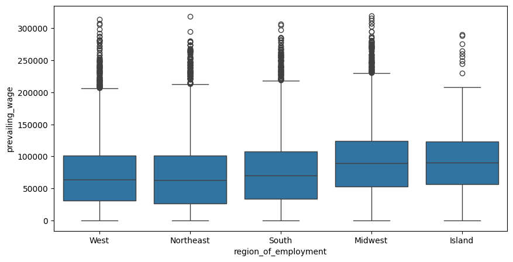

```python
plt.figure(figsize=(10, 5))
sns.boxplot(data=data, x="region_of_employment", y="prevailing_wage")
plt.show()
```

#### Based on the boxplot of prevailing_wage by region_of_employment, the following observations can be made:

##### Varying Median Wages: The median prevailing wage varies noticeably across regions. The South and Midwest regions appear to have comparatively higher median wages, while the Northeast and West record relatively lower median prevailing wages.

##### Right Skewness Across All Regions: The wage distributions across all regions are consistently right-skewed, with the upper whiskers and outliers extending considerably further than the lower end. This indicates that while a wage floor exists — as set by the Department of Labor (DOL) — there is virtually no upper ceiling for highly specialized or senior roles, allowing wages to climb significantly above the median in all regions.

##### Wage Spread and Outliers: All regions exhibit a considerable spread in prevailing wages, as reflected in the length of the boxes and whiskers. Numerous high-end outliers are present across every region, suggesting that certain roles command significantly higher wages regardless of geographic location, pointing to the strong influence of job-specific factors over regional ones.

##### Island Region: The Island region appears to have a slightly higher median wage compared to the Northeast and West, though its relatively small sample size means this observation should be interpreted with some caution.

##### Overlap in Distributions: Despite differences in median wages, there is substantial overlap in wage distributions across most regions. This confirms that high wages can be found in any region and that lower wages are equally present across the board, further reinforcing that geographic location alone is not the primary determinant of prevailing wage.

##### Inference: While regional differences in median prevailing wages do exist, the wide wage ranges, consistent right skewness, and prevalence of high-end outliers across all regions suggest that job-specific factors — such as skill level, industry, and degree of specialization — are at least as influential as, if not more so than, geographic region in determining prevailing wage. This implies that prevailing_wage may carry stronger predictive signal when considered alongside role-specific features rather than in isolation.

## Let's analyze the data and see if the visa status changes with the prevailing wage

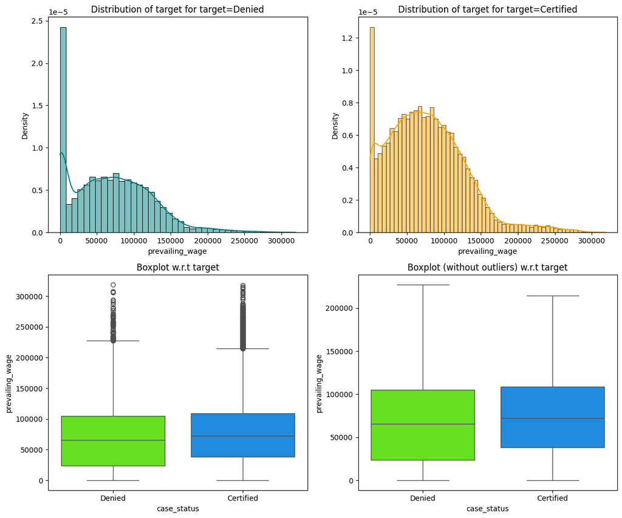

```python
distribution_plot_wrt_target(data, "prevailing_wage", "case_status")
```

#### Based on the distribution plots and boxplots of prevailing_wage with respect to case_status, the following observations can be made:

##### Overlapping Distributions: The histograms for both Certified and Denied cases show significant overlap in their prevailing wage distributions, indicating that a wide range of wages is present in both outcome categories. This overlap suggests that prevailing wage alone is not a reliable discriminator between certified and denied applications.

##### Similar Median Wages: The boxplots reveal that the median prevailing wages for both Certified and Denied cases are quite similar, implying that neither a high nor a low prevailing wage is in itself a decisive determinant of visa outcome. This further supports the view that other features likely carry greater discriminatory power.

##### Outliers Present in Both Categories: Both Certified and Denied applications exhibit high-end outliers in prevailing wage. This confirms that even highly compensated positions can be denied, while some certified positions may offer comparatively modest wages — reinforcing the notion that wage level alone does not determine visa outcome.

##### Slightly Higher Density at Lower Wages for Denied Cases: While the distributions overlap considerably, there is a subtle tendency for Denied cases to show a marginally higher density at the lower end of the prevailing wage spectrum compared to Certified cases. However, this difference is not pronounced enough to serve as a strong or reliable distinguishing factor on its own.

##### Inference: While prevailing_wage is a relevant feature, its individual relationship with case_status does not follow a simple linear pattern. The broad overlap in wage distributions across both outcome categories suggests that other features — such as education level, job experience, and region of employment — are likely to play a more decisive role in determining visa certification. Notably, no clear wage threshold exists that cleanly separates certified from denied cases, which implies that prevailing_wage will likely contribute most effectively to a model when used in combination with other features rather than as a standalone predictor.

## Observations on no_of_employees and case_status

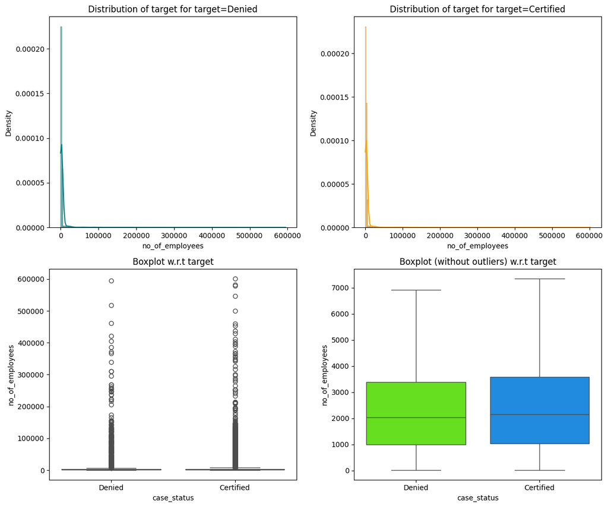

```python
distribution_plot_wrt_target(data, "no_of_employees", "case_status")
```

#### Based on the distribution plots and boxplots of no_of_employees with respect to case_status, the following observations can be made:

##### Heavily Right-Skewed Distributions for Both Categories: The histograms for both Certified and Denied cases reveal a heavily right-skewed distribution for no_of_employees, with the vast majority of applications — regardless of outcome — originating from companies with relatively few employees. A long tail extending toward very large companies is present in both categories, confirming that large employers, while rare, appear in both outcomes.

##### Similar Distribution Shapes: The overall shape of the no_of_employees distribution is remarkably similar across both Certified and Denied cases, with a high concentration at the lower end of the employee count spectrum and a steadily decreasing frequency as company size increases. This similarity in shape suggests that the distribution of company sizes does not differ meaningfully between the two outcome groups.

##### Overlapping Ranges and Medians: The boxplots indicate considerable overlap in both the ranges and median values of no_of_employees across Certified and Denied applications. This suggests that company size, as measured by employee count, is not a strong differentiating factor between approved and rejected visa applications.

##### Outliers Present in Both Categories: Both Certified and Denied applications include cases from companies with exceptionally high employee counts, appearing as outliers on the boxplots. This confirms that even applications from very large corporations can be denied, while certified applications span the full spectrum of company sizes — further undermining no_of_employees as a reliable standalone predictor of visa outcome.

##### Inference: No clearly discernible pattern or threshold in no_of_employees meaningfully separates Certified from Denied visa applications. Companies of all sizes — from small firms to large corporations — appear in both outcome categories in broadly similar proportions. This suggests that no_of_employees is unlikely to be a strong individual predictor of case_status, and that other features such as education level, job experience, and prevailing wage are likely to carry greater discriminatory power in the model.

## Observations on yr_of_estab and case_status

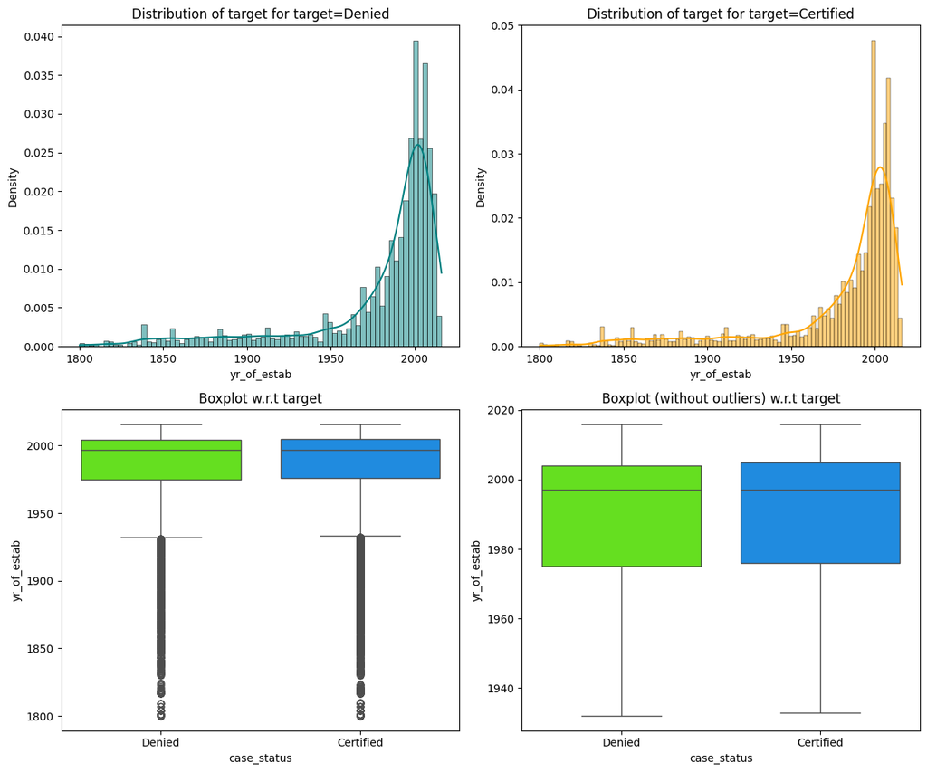

```python
distribution_plot_wrt_target(data, "yr_of_estab", "case_status")
```

#### Based on the distribution plots and boxplots of yr_of_estab with respect to case_status, the following observations can be made:

##### Overlapping Distributions: The histograms for both Certified and Denied cases show considerable overlap in their yr_of_estab distributions, indicating that companies of all ages — both long-established and recently founded — experience visa certifications and denials in broadly similar patterns. This overlap suggests that the year of establishment alone offers limited discriminatory power between the two outcome categories.

##### Similar Central Tendencies: The boxplots reveal that the median year of establishment is quite similar across both Certified and Denied cases, reinforcing the view that company age is not a primary factor in distinguishing visa approvals from denials. The near-identical medians suggest that neither older nor newer companies hold a meaningful advantage in the certification process.

##### Concentration in Recent Decades: Consistent with the earlier univariate analysis, the majority of both Certified and Denied applications are associated with companies established in more recent decades, particularly from the late 20th century onwards. This pattern reflects the broader trend of a higher concentration of younger companies in the dataset rather than any outcome-specific tendency.

##### Full Historical Range Represented in Both Categories: Companies established across the entire historical range of the dataset — from the 19th century through to the early 21st century — are present in both Certified and Denied categories. This confirms that neither a very long nor a very short operating history is predictive of a particular visa outcome.

##### Inference: The year of establishment does not appear to be a strong distinguishing feature for visa certification status. The broadly similar distributions of company age across both Certified and Denied cases suggest that yr_of_estab is unlikely to contribute significant predictive value to the model on its own. As observed with no_of_employees, other features such as education level, job experience, and prevailing wage are likely to be far more influential in determining visa application outcomes.

## Let's find out if it has any impact on visa applications getting certified.

```
case_status   Certified  Denied    All
unit_of_wage
All               17018    8462  25480
Year              16047    6915  22962
Hour                747    1410   2157
Week                169     103    272
Month                55      34     89
------------------------------------------------------------------------------------------------------------------------
```

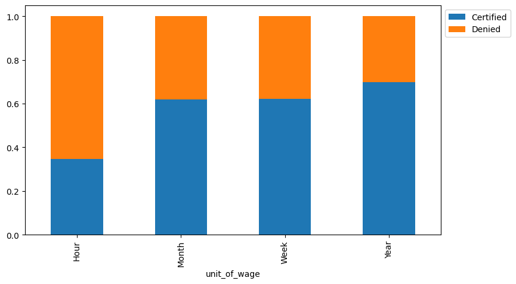

```python
stacked_barplot(data, "unit_of_wage", "case_status")
```

#### Based on the stacked bar plot of unit_of_wage against case_status, the following observations can be made:

##### Dominance of Annual Wage ('Year'): The vast majority of visa applications — approximately 22,962 out of 25,480 — specify year as the unit of wage, making it by far the most common payment frequency in the dataset. This dominance reflects the prevalence of salaried, full-time employment arrangements among visa applicants.

##### Highest Certification Rate for Annual Wage ('Year'): Applications with an annual wage unit record the highest certification rate, with approximately 16,047 out of 22,962 (69.9%) being certified — slightly above the overall dataset average of 66.8%. This suggests that salaried positions are well-aligned with the requirements typically associated with employment-based visa certification.

##### Lowest Certification Rate for Hourly Wage ('Hour'): Applications specifying an hourly wage unit record a significantly lower certification rate of only 34.6% (747 Certified vs. 1,410 Denied out of 2,157 total), making hourly positions the least likely to be certified among all wage units. This stark difference may reflect concerns around job stability, inconsistent income, or the non-specialized nature of roles typically associated with hourly compensation.

##### Moderate Certification Rates for Weekly and Monthly Wage ('Week' and 'Month'): Although considerably fewer in number, applications specifying weekly and monthly wage units show moderate certification rates of approximately 62.1% and 61.8%, respectively. While these rates fall below the annual wage certification rate, they remain closer to the overall dataset average, suggesting that these payment structures occupy a middle ground between the extremes of annual and hourly wage units.

##### Inference: The unit of wage appears to be a meaningful factor in visa certification outcomes. Positions compensated on an hourly basis are considerably less likely to be certified than those paid annually, weekly, or monthly — a disparity that may be attributable to perceived differences in job stability, alignment with salary thresholds, or specific visa requirements that favor salaried full-time equivalent roles. Given the notable variation in certification rates across wage units, unit_of_wage is likely to serve as an informative feature during model training.

## Observations on full_time_position and case_status

[output not shown]

[figure not shown]

```python
stacked_barplot(data, "full_time_position", "case_status")
```

#### Based on the stacked bar plot of full_time_position against case_status, the following observations can be made:

##### Dominance of Full-Time Positions: The vast majority of visa applications are associated with full-time positions, with 22,773 out of 25,480 total cases (89.4%) classified as full-time and only 2,707 (10.6%) as non-full-time. This strong skew toward full-time employment is consistent with the earlier univariate observation and reflects the general preference for full-time arrangements in employment-based visa applications.

##### Certification Rates Across Position Types:For full-time positions (Y), approximately 66.6% of applications were certified (15,163 out of 22,773), with the remaining 33.4% (7,610) denied — closely mirroring the overall dataset certification rate of 66.8%.For non-full-time positions (N), the certification rate is marginally higher at approximately 68.5% (1,855 out of 2,707), with a denial rate of 31.5% (852 out of 2,707).

##### Inference: Despite full-time positions accounting for the overwhelming majority of visa applications, non-full-time positions record a marginally higher certification rate (68.5% vs. 66.6%). This suggests that non-full-time roles do not inherently face a higher likelihood of denial and may, in some cases, be associated with specialized or niche arrangements that satisfy certification requirements. However, the difference between the two groups is relatively small — less than 2 percentage points — and should not be overstated. The sheer volume of full-time applications means they continue to dominate the overall pool of certified cases in absolute terms.

# Data Pre-processing

## Let's check for outliers in the data.

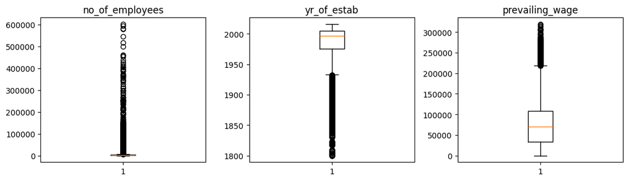

```python
# outlier detection using boxplot
numeric_columns = data.select_dtypes(include=np.number).columns.tolist()


plt.figure(figsize=(15, 12))

for i, variable in enumerate(numeric_columns):
    plt.subplot(4, 4, i + 1)
    plt.boxplot(data[variable], whis=1.5)
    plt.tight_layout()
    plt.title(variable)

plt.show()
```

## Data Preparation for modeling

#### We want to predict which visa will be certified.

#### Before we proceed to build a model, we'll have to encode categorical features.

#### We'll split the data into train and test to be able to evaluate the model that we build on the train data.

```python
data["case_status"] = data["case_status"].apply(lambda x: 1 if x == "Certified" else 0)

X = data.drop(["case_status"], axis=1)
y = data["case_status"]


X = pd.get_dummies(X, drop_first=True)
# X = X.astype(float)

# Splitting data into training, validation and test set:
# first we split data into 2 parts, say temporary and test

X_temp, X_test, y_temp, y_test = train_test_split(
    X, y, test_size=0.2, random_state=1, stratify=y
)

# then we split the temporary set into train and validation

X_train, X_val, y_train, y_val = train_test_split(
    X_temp, y_temp, test_size=0.25, random_state=1, stratify=y_temp
)
```

```python
print("Shape of Training set : ", X_train.shape)
print("Shape of the Validation set: ", X_val.shape)
print("Shape of test set : ", X_test.shape)
print("Percentage of classes in training set:")
print(y_train.value_counts(normalize=True))
print("Percentage of classes in validation set:")
print(y_val.value_counts(normalize=True))
print("Percentage of classes in test set:")
print(y_test.value_counts(normalize=True))
```

```
Shape of Training set :  (15288, 21)
Shape of the Validation set:  (5096, 21)
Shape of test set :  (5096, 21)
Percentage of classes in training set:
case_status
1    0.667844
0    0.332156
Name: proportion, dtype: float64
Percentage of classes in validation set:
case_status
1    0.667975
0    0.332025
Name: proportion, dtype: float64
Percentage of classes in test set:
case_status
1    0.667975
0    0.332025
Name: proportion, dtype: float64
```

## Model Building

### Model evaluation criterion

Model can make wrong predictions as:

The model predicts that the visa application will get certified, but in reality, the visa application gets denied.

Model predicts that the visa application will not get certified but in reality, the visa application get certified. Which case is more important?

Both cases are important as:

If a visa is certified when it should be denied, the wrong employee will get the job position, while US citizens will miss the opportunity to work in that position.

If a visa is denied when it had to be certified, the U.S. will lose a suitable human resource that can contribute to the economy.

How to reduce the losses?

F1 Score can be used as a metric for evaluation of the model; the greater the F1 score, the higher the chances of minimizing False Negatives and False Positives.

We will use balanced class weights so that the model focuses equally on both classes.

First, let's create functions to calculate different metrics and a confusion matrix so that we don't have to use the same code repeatedly for each model.

The model_performance_classification_sklearn function will be used to check the model performance of models.

```python
# defining a function to compute different metrics to check performance of a classification model built using sklearn


def model_performance_classification_sklearn(model, predictors, target):
    """
    Function to compute different metrics to check classification model performance

    model: classifier
    predictors: independent variables
    target: dependent variable
    """

    # predicting using the independent variables
    pred = model.predict(predictors)

    acc = accuracy_score(target, pred)  # to compute Accuracy
    recall = recall_score(target, pred)  # to compute Recall
    precision = precision_score(target, pred)  # to compute Precision
    f1 = f1_score(target, pred)  # to compute F1-score

    # creating a dataframe of metrics
    df_perf = pd.DataFrame(
        {"Accuracy": acc, "Recall": recall, "Precision": precision, "F1": f1,},
        index=[0],
    )

    return df_perf
```

## Model Building - Original Data

```python
# The Models (Different algorithms)
from sklearn.ensemble import BaggingClassifier, RandomForestClassifier, GradientBoostingClassifier, AdaBoostClassifier
from xgboost import XGBClassifier

# The Grading Scale (To see if they are right)
from sklearn.metrics import f1_score, accuracy_score, recall_score, precision_score, confusion_matrix

# Tools for plotting
import matplotlib.pyplot as plt
import seaborn as sns
```

```python
models = []

# 1. Bagging: Takes a vote among many trees
models.append(("Bagging", BaggingClassifier(random_state=1)))

# 2. Random Forest: A smarter version of Bagging
models.append(("Random Forest", RandomForestClassifier(random_state=1, class_weight="balanced")))

# 3. GBM: Builds trees one after another to fix errors
models.append(("GBM", GradientBoostingClassifier(random_state=1)))

# 4. AdaBoost: Focuses heavily on the 'hard' cases
models.append(("Adaboost", AdaBoostClassifier(random_state=1)))

# 5. XGBoost: The fastest and usually the most accurate booster
models.append(("XGBoost", XGBClassifier(random_state=1, eval_metric='logloss')))

print("\n" "Training Performance:" "\n")
for name, model in models:
    model.fit(X_train, y_train)
    scores = f1_score(y_train, model.predict(X_train))
    print("{}: {}".format(name, scores))

print("\n" "Validation Performance:" "\n")

for name, model in models:
    model.fit(X_train, y_train)
    scores_val = f1_score(y_val, model.predict(X_val))
    print("{}: {}".format(name, scores_val))
```

```
Training Performance:

Bagging: 0.9890530656325168
Random Forest: 1.0
GBM: 0.8291218182658106
Adaboost: 0.8204269947530306
XGBoost: 0.8963229453814886

Validation Performance:

Bagging: 0.7737656595431098
Random Forest: 0.8048301039033979
GBM: 0.826637008202419
Adaboost: 0.8180081855388813
XGBoost: 0.8079119654547987
```

```python
print(f"{'Model Name':<15} | {'Train F1':<10} | {'Val F1':<10} | {'Difference':<10}")
print("-" * 55)

for name, model in models:
    # 1. Fit the model
    model.fit(X_train, y_train)

    # 2. Get predictions for both sets
    train_pred = model.predict(X_train)
    val_pred = model.predict(X_val)

    # 3. Calculate F1-scores
    f1_train = f1_score(y_train, train_pred)
    f1_val = f1_score(y_val, val_pred)

    # 4. Calculate the difference (the "Overfitting Gap")
    diff = f1_train - f1_val

    print(f"{name:<15} | {f1_train:<10.4f} | {f1_val:<10.4f} | {diff:<10.4f}")
```

```
Model Name      | Train F1   | Val F1     | Difference
-------------------------------------------------------
Bagging         | 0.9891     | 0.7738     | 0.2153
Random Forest   | 1.0000     | 0.8048     | 0.1952
GBM             | 0.8291     | 0.8266     | 0.0025
Adaboost        | 0.8204     | 0.8180     | 0.0024
XGBoost         | 0.8963     | 0.8079     | 0.0884
```

#### Based on the F1 scores from the training and validation sets, the following observations can be made regarding model performance:

##### Significant Overfitting in Bagging and Random Forest: Both the Bagging and Random Forest models achieve very high F1 scores on the training data (Bagging: 0.9891, Random Forest: 1.0000), but their performance drops considerably on the validation set (Bagging: 0.7737, Random Forest: 0.8048). The large gap between training and validation scores (Bagging: 0.2153, Random Forest: 0.1952) is a strong indicator of overfitting — both models have memorized the training data rather than learning generalizable patterns, resulting in poor performance on unseen data.

##### Strong Generalization in GBM and AdaBoost: The Gradient Boosting Machine (GBM) and AdaBoost models demonstrate highly consistent F1 scores across both the training and validation sets, with minimal differences of 0.0025 and 0.0024, respectively. This negligible gap between training and validation performance suggests that both models are generalizing effectively to unseen data with little to no overfitting.

##### Moderate Overfitting in XGBoost: XGBoost achieves a solid training F1 score of 0.8963, but records a noticeable drop to 0.8079 on the validation set — a difference of 0.0884. While this indicates some degree of overfitting, it is considerably less severe than that observed in the Bagging and Random Forest models, positioning XGBoost as a middle ground between the extremes.

##### Best Validation Performance — GBM: Among all models evaluated, the Gradient Boosting Machine achieves the highest validation F1 score of 0.8266, closely followed by AdaBoost at 0.8180. This suggests that GBM currently offers the best balance between bias and variance for this dataset, making it the most robust and reliable model at this stage of evaluation.

## Model Building - Oversampled Data

```python
print("Before Oversampling, counts of label 'Certified': {}".format(sum(y_train == 1)))
print("Before Oversampling, counts of label 'Denied': {} \n".format(sum(y_train == 0)))

sm = SMOTE(
    sampling_strategy=1, k_neighbors=5, random_state=1
)  # Synthetic Minority Over Sampling Technique
X_train_over, y_train_over = sm.fit_resample(X_train, y_train)


print("After Oversampling, counts of label 'Certified': {}".format(sum(y_train_over == 1)))
print("After Oversampling, counts of label 'Denied': {} \n".format(sum(y_train_over == 0)))


print("After Oversampling, the shape of train_X: {}".format(X_train_over.shape))
print("After Oversampling, the shape of train_y: {} \n".format(y_train_over.shape))
```

```
Before Oversampling, counts of label 'Certified': 10210
Before Oversampling, counts of label 'Denied': 5078

After Oversampling, counts of label 'Certified': 10210
After Oversampling, counts of label 'Denied': 10210

After Oversampling, the shape of train_X: (20420, 21)
After Oversampling, the shape of train_y: (20420,)
```

```python
# 1. Complete the model list
models = []
models.append(("Bagging", BaggingClassifier(random_state=1)))
models.append(("Random Forest", RandomForestClassifier(random_state=1)))
models.append(("GBM", GradientBoostingClassifier(random_state=1)))
models.append(("Adaboost", AdaBoostClassifier(random_state=1)))
models.append(("XGBoost", XGBClassifier(random_state=1, eval_metric='logloss')))

print("\n" "Training Performance (Oversampled Data):" "\n")
for name, model in models:
    # We train on the NEW oversampled data
    model.fit(X_train_over, y_train_over)

    # We check the score on the SAME oversampled data
    scores = f1_score(y_train_over, model.predict(X_train_over))
    print("{}: {:.4f}".format(name, scores))

print("\n" "Validation Performance (Original Data):" "\n")
for name, model in models:
    # Note: The model is already trained from the loop above,
    # but we test it on the UNTOUCHED validation set.
    scores = f1_score(y_val, model.predict(X_val))
    print("{}: {:.4f}".format(name, scores))
```

```
Training Performance (Oversampled Data):

Bagging: 0.9877
Random Forest: 1.0000
GBM: 0.8072
Adaboost: 0.8005
XGBoost: 0.8709

Validation Performance (Original Data):

Bagging: 0.7682
Random Forest: 0.7953
GBM: 0.8173
Adaboost: 0.8195
XGBoost: 0.8129
```

```python
print(f"{'Model Name':<15} | {'Train F1 (Over)':<15} | {'Val F1 (Orig)':<15} | {'Difference':<10}")
print("-" * 65)

for name, model in models:
    # 1. Train on the synthetic oversampled data
    model.fit(X_train_over, y_train_over)

    # 2. Get predictions
    train_pred = model.predict(X_train_over)
    val_pred = model.predict(X_val)

    # 3. Calculate F1-scores
    f1_train = f1_score(y_train_over, train_pred)
    f1_val = f1_score(y_val, val_pred)

    # 4. Calculate the difference
    diff = f1_train - f1_val

    print(f"{name:<15} | {f1_train:<15.4f} | {f1_val:<15.4f} | {diff:<10.4f}")
```

```
Model Name      | Train F1 (Over) | Val F1 (Orig)   | Difference
-----------------------------------------------------------------
Bagging         | 0.9877          | 0.7682          | 0.2195
Random Forest   | 1.0000          | 0.7953          | 0.2047
GBM             | 0.8072          | 0.8173          | -0.0101
Adaboost        | 0.8005          | 0.8195          | -0.0190
XGBoost         | 0.8709          | 0.8129          | 0.0579
```

#### Based on the F1 scores following oversampling with SMOTE, the following observations can be made:

##### Best Overall Performance — AdaBoost: AdaBoost emerges as the best-performing model after oversampling, achieving the highest validation F1 score of 0.8195. Notably, its training F1 (0.8005) and validation F1 (0.8195) are remarkably close, yielding a negative difference of -0.0190. This near-identical performance across both sets is a strong indicator of excellent generalization, confirming that AdaBoost is not overfitting the training data.

##### Strong Performance from GBM and XGBoost: The Gradient Boosting Machine (GBM) continues to perform strongly, recording a validation F1 of 0.8173 and an even smaller training-to-validation difference of -0.0101, reflecting outstanding generalization. XGBoost also delivers a competitive validation F1 of 0.8129, though its slightly larger difference of 0.0579 suggests a minor degree of overfitting relative to AdaBoost and GBM — an issue that may be addressable through further hyperparameter tuning.

##### Persistent Overfitting in Bagging and Random Forest: Despite the introduction of SMOTE, the Bagging and Random Forest models continue to exhibit significant overfitting, with notably high training F1 scores that fail to translate into comparable validation performance. The large gap between their training and validation scores remains a concern, and these models lag behind the ensemble boosting methods in terms of generalization ability.

##### Impact of SMOTE on Model Performance: Prior to oversampling, GBM held a marginal lead in validation performance. However, the introduction of additional Denied examples via SMOTE appears to have particularly benefited AdaBoost, which is architecturally designed to focus on difficult-to-classify instances. By exposing AdaBoost to a more balanced representation of the minority class, SMOTE enabled the model to refine its decision boundaries for Denied cases more effectively, ultimately allowing it to surpass GBM as the top-performing model.

##### Overall: The application of SMOTE has produced a meaningful shift in the model rankings, with AdaBoost emerging as the strongest performer in terms of both validation F1 score and generalization. GBM remains a close and reliable alternative, while XGBoost warrants further tuning. Bagging and Random Forest continue to underperform relative to the boosting-based models and may require more aggressive regularization or alternative resampling strategies to address their persistent overfitting.

## Model Building - Undersampled Data

```python
from imblearn.under_sampling import RandomUnderSampler
```

```python
rus = RandomUnderSampler(random_state=1)
X_train_un, y_train_un = rus.fit_resample(X_train, y_train)
```

```python
print("Before Under Sampling, counts of label 'Certified': {}".format(sum(y_train == 1)))
print("Before Under Sampling, counts of label 'Denied': {} \n".format(sum(y_train == 0)))

print("After Under Sampling, counts of label 'Certified': {}".format(sum(y_train_un == 1)))
print("After Under Sampling, counts of label 'Denied': {} \n".format(sum(y_train_un == 0)))

print("After Under Sampling, the shape of train_X: {}".format(X_train_un.shape))
print("After Under Sampling, the shape of train_y: {} \n".format(y_train_un.shape))
```

```
Before Under Sampling, counts of label 'Certified': 10210
Before Under Sampling, counts of label 'Denied': 5078

After Under Sampling, counts of label 'Certified': 5078
After Under Sampling, counts of label 'Denied': 5078

After Under Sampling, the shape of train_X: (10156, 21)
After Under Sampling, the shape of train_y: (10156,)
```

```python
# 1. Complete the model list
models = []
models.append(("Bagging", BaggingClassifier(random_state=1)))
models.append(("Random Forest", RandomForestClassifier(random_state=1)))
models.append(("GBM", GradientBoostingClassifier(random_state=1)))
models.append(("Adaboost", AdaBoostClassifier(random_state=1)))
models.append(("XGBoost", XGBClassifier(random_state=1, eval_metric='logloss')))

print("\n" "Training Performance (Undersampled Data):" "\n")
for name, model in models:
    # We train on the NEW undersampled data
    model.fit(X_train_un, y_train_un)

    # We check the score on the SAME undersampled data
    scores = f1_score(y_train_un, model.predict(X_train_un))
    print("{}: {:.4f}".format(name, scores))

print("\n" "Validation Performance (Original Data):" "\n")
for name, model in models:
    # The model is already trained, we just test it on the untouched validation set
    scores = f1_score(y_val, model.predict(X_val))
    print("{}: {:.4f}".format(name, scores))
```

```
Training Performance (Undersampled Data):

Bagging: 0.9809
Random Forest: 1.0000
GBM: 0.7281
Adaboost: 0.7015
XGBoost: 0.8720

Validation Performance (Original Data):

Bagging: 0.7050
Random Forest: 0.7397
GBM: 0.7766
Adaboost: 0.7660
XGBoost: 0.7459
```

```python
print(f"{'Model Name':<15} | {'Train F1 (Un)':<15} | {'Val F1 (Orig)':<15} | {'Difference':<10}")
print("-" * 65)

for name, model in models:
    # 1. Train on the shrunken, undersampled data
    model.fit(X_train_un, y_train_un)

    # 2. Get predictions
    train_pred = model.predict(X_train_un)
    val_pred = model.predict(X_val)

    # 3. Calculate F1-scores
    f1_train = f1_score(y_train_un, train_pred)
    f1_val = f1_score(y_val, val_pred)

    # 4. Calculate the difference
    diff = f1_train - f1_val

    print(f"{name:<15} | {f1_train:<15.4f} | {f1_val:<15.4f} | {diff:<10.4f}")
```

```
Model Name      | Train F1 (Un)   | Val F1 (Orig)   | Difference
-----------------------------------------------------------------
Bagging         | 0.9809          | 0.7050          | 0.2759
Random Forest   | 1.0000          | 0.7397          | 0.2603
GBM             | 0.7281          | 0.7766          | -0.0485
Adaboost        | 0.7015          | 0.7660          | -0.0645
XGBoost         | 0.8720          | 0.7459          | 0.1261
```

#### Based on the undersampling results, the following observations can be made by comparing validation F1 scores across all three data preparation methods:

##### ModelOriginal Data (Val F1) SMOTE Oversampled (Val F1) Undersampled (Val F1)

##### GBM 0.8266, 0.8173, 0.7766

##### AdaBoost 0.8180, 0.8195, 0.7660

##### Overall Decrease in Validation F1 Scores: Compared to both the original and oversampled data, the validation F1 scores for most models decline notably when trained on undersampled data. This suggests that removing thousands of Certified examples in order to balance the classes deprives the models of valuable information needed to understand the nuances of the certification decision, ultimately resulting in poorer performance on the validation set.

##### Underfitting in GBM and AdaBoost: The training F1 scores for GBM (0.7281) and AdaBoost (0.7015) are considerably lower than those achieved under SMOTE or the original data. These reduced training scores indicate that both models are underfitting — a direct consequence of having insufficient training examples to learn the underlying patterns of the data effectively.

##### Persistent Overfitting in Random Forest: Despite the significant reduction in training data size introduced by undersampling, Random Forest continues to achieve a perfect training F1 score of 1.0000. This confirms that the model is still memorizing the training rows rather than learning generalizable decision logic — a persistent weakness that undersampling alone is insufficient to resolve.

##### Good Generalization but Lower Scores in GBM and AdaBoost: GBM and AdaBoost continue to demonstrate strong generalization under undersampling, with negative training-to-validation differences of -0.0485 and -0.0645, respectively, confirming the absence of overfitting. However, their validation F1 scores (GBM: 0.7766, AdaBoost: 0.7660) fall meaningfully short of what both models achieved with the original and oversampled data, indicating that good generalization alone is not sufficient when the underlying training signal is too weak.

##### Final Decision: Based on the comparative results across all three approaches, the original data and SMOTE oversampling are the clear preferred strategies, both delivering higher and more stable validation F1 scores than undersampling.

##### Between the two: The original data yielded a slightly higher validation F1 for GBM (0.8266).

##### SMOTE produced a marginally better result for AdaBoost (0.8195) and is likely to improve the model's ability to correctly identify Denied cases by providing a more balanced representation of the minority class during training.

##### Inference: Undersampling has generally proven detrimental in this context, leading to a consistent decline in validation F1 scores across all models relative to the original and oversampled data. While undersampling is a valid technique for addressing class imbalance, the reduction in overall training data size in this case appears to have hindered the models' ability to learn complex relationships within the data. Oversampling via SMOTE offers a more effective balance between class representation and data richness, and alongside the original data, represents the stronger foundation for final model selection and hyperparameter tuning.

## Hyperparameter Tuning - Random Forest

```python
from sklearn import metrics
from sklearn.model_selection import GridSearchCV
import numpy as np
```

```python
%%time
# Choose the type of classifier.
rf_tuned = RandomForestClassifier(random_state=1, oob_score=True, bootstrap=True)

parameters = {
    "max_depth": list(np.arange(5, 15, 5)),
    "max_features": ["sqrt", "log2"],
    "min_samples_split": [3, 5, 7],
    "n_estimators": np.arange(10, 40, 10),
}

# Type of scoring used to compare parameter combinations
acc_scorer = metrics.make_scorer(metrics.f1_score)

# Run the grid search
grid_obj = GridSearchCV(rf_tuned, parameters, scoring=acc_scorer, cv=5, n_jobs=-1)
grid_obj = grid_obj.fit(X_train_over, y_train_over)

# Set the clf to the best combination of parameters
rf_tuned = grid_obj.best_estimator_

# Fit the best algorithm to the data.
rf_tuned.fit(X_train, y_train)
```

[output not shown]

[output cut: 65 more lines]

[output not shown]

```
CPU times: user 684 ms, sys: 275 ms, total: 958 ms
Wall time: 8.74 s
```

```
RandomForestClassifier(max_depth=np.int64(10), min_samples_split=5,
                       n_estimators=np.int64(30), oob_score=True,
                       random_state=1)
```

## Checking model performance on training set

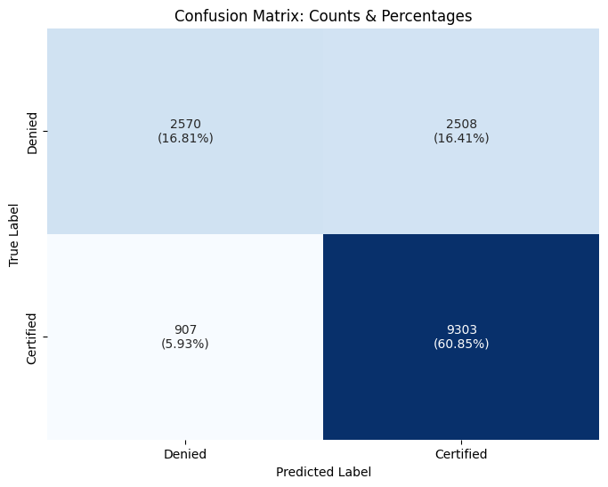

```python
from sklearn.metrics import confusion_matrix
import matplotlib.pyplot as plt
import seaborn as sns
import numpy as np

# 1. Get predictions
y_pred = rf_tuned.predict(X_train)

# 2. Create the raw confusion matrix
cm = confusion_matrix(y_train, y_pred)

# 3. Calculate percentages
# We divide each box by the total sum of all boxes
cm_percent = cm.astype('float') / cm.sum() * 100

# 4. Create labels combining Count and Percentage
# This creates strings like "1500 \n (45.2%)"
labels = (np.array(["{0:d}\n({1:.2f}%)".format(count, percent)
          for count, percent in zip(cm.flatten(), cm_percent.flatten())]
         )).reshape(2,2)

# 5. Plot using Seaborn for better control
plt.figure(figsize=(8, 6))
sns.heatmap(cm, annot=labels, fmt="", cmap='Blues', cbar=False,
            xticklabels=["Denied", "Certified"],
            yticklabels=["Denied", "Certified"])

plt.xlabel('Predicted Label')
plt.ylabel('True Label')
plt.title('Confusion Matrix: Counts & Percentages')
plt.show()
```

```python
rf_tuned_model_train_perf = model_performance_classification_sklearn(
    rf_tuned, X_train, y_train
)
rf_tuned_model_train_perf
```

|  | Accuracy | Recall | Precision | F1 |
| --- | --- | --- | --- | --- |
| 0 | 0.776622 | 0.911166 | 0.787656 | 0.844921 |

## Checking model performance on validation set

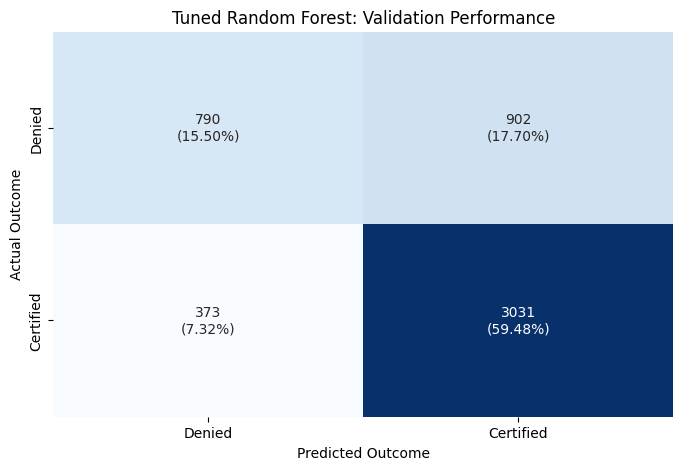

```python
import seaborn as sns
import numpy as np
from sklearn.metrics import confusion_matrix
import matplotlib.pyplot as plt

# 1. Generate predictions for the Validation set
y_pred = rf_tuned.predict(X_val)

# 2. Compute the confusion matrix
cm = confusion_matrix(y_val, y_pred)

# 3. Calculate percentages (relative to the total number of cases)
# This gives you the 'Global' percentage for each box
cm_percent = cm.astype('float') / cm.sum() * 100

# 4. Create the labels: "Count \n (Percentage%)"
labels = (np.array(["{0:d}\n({1:.2f}%)".format(count, percent)
          for count, percent in zip(cm.flatten(), cm_percent.flatten())]
         )).reshape(2,2)

# 5. Plot using a heatmap
plt.figure(figsize=(8, 5))
sns.heatmap(cm, annot=labels, fmt="", cmap='Blues', cbar=False,
            xticklabels=["Denied", "Certified"],
            yticklabels=["Denied", "Certified"])

plt.title("Tuned Random Forest: Validation Performance")
plt.xlabel("Predicted Outcome")
plt.ylabel("Actual Outcome")
plt.show()
```

```python
rf_tuned_model_val_perf = model_performance_classification_sklearn(
    rf_tuned, X_val, y_val
)
rf_tuned_model_val_perf
```

|  | Accuracy | Recall | Precision | F1 |
| --- | --- | --- | --- | --- |
| 0 | 0.749804 | 0.890423 | 0.770659 | 0.826223 |

#### Based on the tuned Random Forest model's performance on both the training and validation sets, the following observations can be made:

##### F1 Score: The tuned Random Forest model achieves an F1 score of 0.8449 on the training set and 0.8262 on the validation set, representing a difference of only 0.0187. This negligible gap between training and validation performance indicates that hyperparameter tuning has been effective in significantly reducing the overfitting that was previously observed in the untuned model, resulting in considerably improved generalization to unseen data.

##### Recall: The model records a high recall score of 0.9112 on the training set and 0.8904 on the validation set. The consistency of these scores across both sets confirms that the model is effectively identifying a large proportion of actual Certified cases, with very few true positives being missed.

##### Precision: Precision scores of 0.7877 on the training set and 0.7707 on the validation set, while slightly lower than the corresponding recall scores, remain at a solid level. This indicates a relatively low rate of false positives — meaning the model is not excessively certifying applications that should have been denied.

##### Overall: Hyperparameter tuning has meaningfully improved the Random Forest model's generalization capability, substantially closing the training-to-validation performance gap that characterized the untuned version. With strong and consistent recall scores, solid precision, and a well-balanced F1 score on the validation set, the tuned Random Forest model emerges as a strong candidate for predicting visa certification outcomes — effectively balancing the trade-off between precision and recall.

## Hyperparameter Tuning - AdaBoost Classifier

```python
%%time
# Choose the type of classifier.
abc_tuned = AdaBoostClassifier(random_state=1)

# Grid of parameters to choose from
parameters = {
    # Let's try different max_depth for base_estimator
    "estimator": [
        DecisionTreeClassifier(max_depth=2, random_state=1),
        DecisionTreeClassifier(max_depth=3, random_state=1),
    ],
    "n_estimators": np.arange(50,110,25),
    "learning_rate": np.arange(0.01,0.1,0.05),
}

# Type of scoring used to compare parameter  combinations
acc_scorer = metrics.make_scorer(metrics.f1_score)

# Run the grid search
grid_obj = GridSearchCV(abc_tuned, parameters, scoring=acc_scorer, cv=5, n_jobs=-1)  ## Complete the code to define the grid search object
grid_obj = grid_obj.fit(X_train, y_train)

# Set the clf to the best combination of parameters
abc_tuned = grid_obj.best_estimator_

# Fit the best algorithm to the data.
abc_tuned.fit(X_train, y_train)
```

```
CPU times: user 2.5 s, sys: 205 ms, total: 2.71 s
Wall time: 13.4 s
```

```
AdaBoostClassifier(estimator=DecisionTreeClassifier(max_depth=3,
                                                    random_state=1),
                   learning_rate=np.float64(0.060000000000000005),
                   n_estimators=np.int64(100), random_state=1)
```

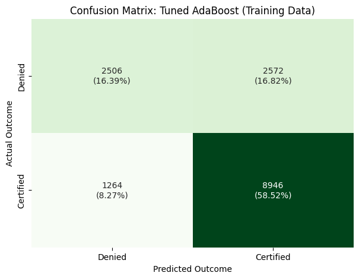

```python
from sklearn.metrics import confusion_matrix
import seaborn as sns
import numpy as np
import matplotlib.pyplot as plt

# 1. Generate predictions for the training set
y_pred_train = abc_tuned.predict(X_train)

# 2. Compute the confusion matrix
cm = confusion_matrix(y_train, y_pred_train)

# 3. Calculate percentages relative to the total number of cases
cm_percent = cm.astype('float') / cm.sum() * 100

# 4. Create text labels: "Count \n (Percentage%)"
labels = (np.array(["{0:d}\n({1:.2f}%)".format(count, percent)
          for count, percent in zip(cm.flatten(), cm_percent.flatten())]
         )).reshape(2,2)

# 5. Plotting with Seaborn
plt.figure(figsize=(7, 5))
sns.heatmap(cm, annot=labels, fmt="", cmap='Greens', cbar=False,
            xticklabels=["Denied", "Certified"],
            yticklabels=["Denied", "Certified"])

plt.title("Confusion Matrix: Tuned AdaBoost (Training Data)")
plt.xlabel("Predicted Outcome")
plt.ylabel("Actual Outcome")
plt.show()
```

```python
abc_tuned_model_train_perf = model_performance_classification_sklearn(
    abc_tuned, X_train, y_train
)
abc_tuned_model_train_perf
```

|  | Accuracy | Recall | Precision | F1 |
| --- | --- | --- | --- | --- |
| 0 | 0.749084 | 0.8762 | 0.776697 | 0.823454 |

## Checking model performance on validation set

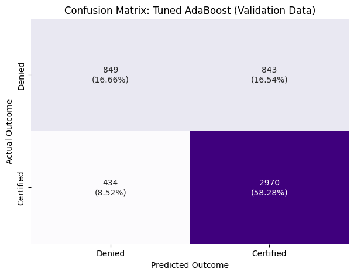

```python
from sklearn.metrics import confusion_matrix
import seaborn as sns
import numpy as np
import matplotlib.pyplot as plt

# 1. Generate predictions for the validation set
y_pred_val = abc_tuned.predict(X_val)

# 2. Compute the confusion matrix
cm = confusion_matrix(y_val, y_pred_val)

# 3. Calculate percentages relative to the total number of validation cases
cm_percent = cm.astype('float') / cm.sum() * 100

# 4. Create text labels: "Count \n (Percentage%)"
labels = (np.array(["{0:d}\n({1:.2f}%)".format(count, percent)
          for count, percent in zip(cm.flatten(), cm_percent.flatten())]
         )).reshape(2,2)

# 5. Plotting with Seaborn
plt.figure(figsize=(7, 5))
sns.heatmap(cm, annot=labels, fmt="", cmap='Purples', cbar=False,
            xticklabels=["Denied", "Certified"],
            yticklabels=["Denied", "Certified"])

plt.title("Confusion Matrix: Tuned AdaBoost (Validation Data)")
plt.xlabel("Predicted Outcome")
plt.ylabel("Actual Outcome")
plt.show()
```

```python
abc_tuned_model_val_perf = model_performance_classification_sklearn(
    abc_tuned, X_val, y_val
)
abc_tuned_model_val_perf
```

|  | Accuracy | Recall | Precision | F1 |
| --- | --- | --- | --- | --- |
| 0 | 0.749411 | 0.872503 | 0.778914 | 0.823057 |

#### Based on the tuned AdaBoost Classifier's performance on both the training and validation sets, the following observations can be made:

##### F1 Score: The tuned AdaBoost Classifier achieves an F1 score of 0.8235 on the training set and 0.8231 on the validation set, with a negligible difference of just 0.0004 between the two. This near-identical performance across both sets is a strong indicator of excellent generalization, confirming that the model is learning robust and transferable patterns rather than memorizing the training data. Virtually no overfitting is observed.

##### Recall: The model records consistently high recall scores of 0.8762 on the training set and 0.8725 on the validation set. The minimal drop between the two confirms that the model is highly effective at correctly identifying the majority of actual Certified visa applications, with very few true positives being missed across both sets.

##### Precision: Precision scores of 0.7767 on the training set and 0.7789 on the validation set are not only solid in absolute terms but also noteworthy in that the validation precision marginally exceeds the training precision. This slight improvement on unseen data suggests that the model's positive predictions are reliable and that the rate of false positives remains well controlled.

##### Inference: The tuned AdaBoost Classifier distinguishes itself through its exceptional generalization and well-balanced performance across all three metrics. The near-zero gap between training and validation F1 scores (0.0004) represents the smallest overfitting margin observed among all models evaluated, making it the most stable and consistent performer in this analysis. While its absolute F1 scores are comparable to those of the tuned Random Forest model, AdaBoost's significantly tighter training-to-validation gap gives it a meaningful edge in terms of reliability and robustness — qualities that are particularly valuable when deploying a model to predict outcomes on truly unseen data.

### Hyperparameter Tuning - Gradient Boosting Classifier

```python
%%time
# Choose the type of classifier.
gbc_tuned = GradientBoostingClassifier(
    init=AdaBoostClassifier(random_state=1), random_state=1
)

# Grid of parameters to choose from
parameters = {
    "n_estimators": np.arange(50,110,25),
    "subsample": [0.7,0.9],
    "max_features": [0.7, 0.8, 0.9, 1],
    "learning_rate": [0.01,0.1,0.05],
}

# Type of scoring used to compare parameter combinations
acc_scorer = metrics.make_scorer(metrics.f1_score)

# Run the grid search
grid_obj = GridSearchCV(gbc_tuned, parameters, scoring=acc_scorer, cv=5, n_jobs=-1)
grid_obj = grid_obj.fit(X_train, y_train)

# Set the clf to the best combination of parameters
gbc_tuned = grid_obj.best_estimator_

# Fit the best algorithm to the data.
gbc_tuned.fit(X_train, y_train)
```

```
CPU times: user 1.84 s, sys: 706 ms, total: 2.55 s
Wall time: 58.1 s
```

```
GradientBoostingClassifier(init=AdaBoostClassifier(random_state=1),
                           learning_rate=0.05, max_features=0.7,
                           n_estimators=np.int64(50), random_state=1,
                           subsample=0.7)
```

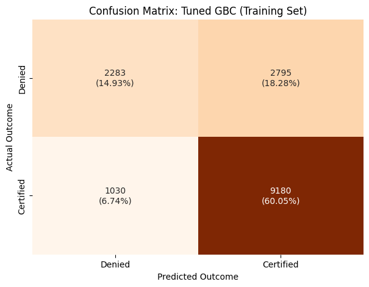

```python
from sklearn.metrics import confusion_matrix
import seaborn as sns
import numpy as np
import matplotlib.pyplot as plt

# 1. Generate predictions using your tuned GBC model
y_pred_train = gbc_tuned.predict(X_train)

# 2. Compute the confusion matrix
cm = confusion_matrix(y_train, y_pred_train)

# 3. Calculate percentages relative to the total samples
cm_percent = cm.astype('float') / cm.sum() * 100

# 4. Create text labels: "Count \n (Percentage%)"
labels = (np.array(["{0:d}\n({1:.2f}%)".format(count, percent)
          for count, percent in zip(cm.flatten(), cm_percent.flatten())]
         )).reshape(2,2)

# 5. Plotting
plt.figure(figsize=(7, 5))
sns.heatmap(cm, annot=labels, fmt="", cmap='Oranges', cbar=False,
            xticklabels=["Denied", "Certified"],
            yticklabels=["Denied", "Certified"])

plt.title("Confusion Matrix: Tuned GBC (Training Set)")
plt.xlabel("Predicted Outcome")
plt.ylabel("Actual Outcome")
plt.show()
```

```python
gbc_tuned_model_train_perf = model_performance_classification_sklearn(gbc_tuned, X_train, y_train)
gbc_tuned_model_train_perf
```

|  | Accuracy | Recall | Precision | F1 |
| --- | --- | --- | --- | --- |
| 0 | 0.749804 | 0.899119 | 0.766597 | 0.827586 |

## Checking model performance on validation set

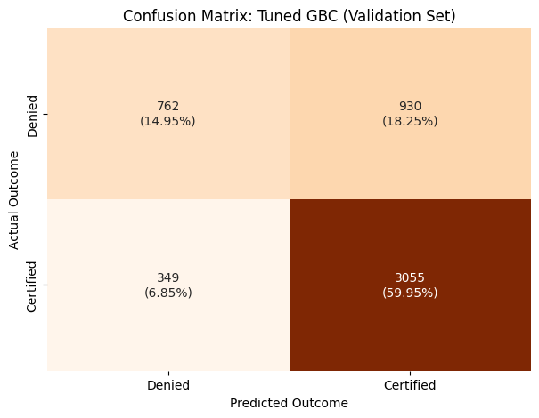

```python
from sklearn.metrics import confusion_matrix
import seaborn as sns
import numpy as np
import matplotlib.pyplot as plt

# 1. Generate predictions using your tuned GBC model on Validation data
y_pred_val = gbc_tuned.predict(X_val)

# 2. Compute the confusion matrix
cm = confusion_matrix(y_val, y_pred_val)

# 3. Calculate percentages relative to the total validation samples
cm_percent = cm.astype('float') / cm.sum() * 100

# 4. Create labels: "Count \n (Percentage%)"
labels = (np.array(["{0:d}\n({1:.2f}%)".format(count, percent)
          for count, percent in zip(cm.flatten(), cm_percent.flatten())]
         )).reshape(2,2)

# 5. Plotting
plt.figure(figsize=(7, 5))
sns.heatmap(cm, annot=labels, fmt="", cmap='Oranges', cbar=False,
            xticklabels=["Denied", "Certified"],
            yticklabels=["Denied", "Certified"])

plt.title("Confusion Matrix: Tuned GBC (Validation Set)")
plt.xlabel("Predicted Outcome")
plt.ylabel("Actual Outcome")
plt.show()
```

```python
gbc_tuned_model_val_perf = model_performance_classification_sklearn(gbc_tuned, X_val, y_val)
gbc_tuned_model_val_perf
```

|  | Accuracy | Recall | Precision | F1 |
| --- | --- | --- | --- | --- |
| 0 | 0.749019 | 0.897474 | 0.766625 | 0.826905 |

### Hyperparameter Tuning - XGBoost Classifier

```python
%%time
# Choose the type of classifier.
xgb_tuned = XGBClassifier(random_state=1, eval_metric="logloss")

# Grid of parameters to choose from
parameters = {
    "n_estimators": np.arange(50,110,25),
    "scale_pos_weight": [1,2,5],
    "subsample": [0.9, 1],
    "learning_rate": [0.01,0.1,0.05],
    "gamma": [1,3]
}

# Type of scoring used to compare parameter combinations
acc_scorer = metrics.make_scorer(metrics.f1_score)

# Run the grid search
grid_obj = GridSearchCV(
    estimator=xgb_tuned,
    param_grid=parameters,
    scoring=acc_scorer,
    cv=5,
    n_jobs=-1
)
grid_obj = grid_obj.fit(X_train_over, y_train_over)

# Set the clf to the best combination of parameters
xgb_tuned = grid_obj.best_estimator_

# Fit the best algorithm to the data.
xgb_tuned.fit(X_train, y_train)
```

```
CPU times: user 1.17 s, sys: 807 ms, total: 1.98 s
Wall time: 16.9 s
```

```
XGBClassifier(base_score=None, booster=None, callbacks=None,
              colsample_bylevel=None, colsample_bynode=None,
              colsample_bytree=None, device=None, early_stopping_rounds=None,
              enable_categorical=False, eval_metric='logloss',
              feature_types=None, feature_weights=None, gamma=1,
              grow_policy=None, importance_type=None,
              interaction_constraints=None, learning_rate=0.1, max_bin=None,
              max_cat_threshold=None, max_cat_to_onehot=None,
              max_delta_step=None, max_depth=None, max_leaves=None,
              min_child_weight=None, missing=nan, monotone_constraints=None,
              multi_strategy=None, n_estimators=np.int64(100), n_jobs=None,
              num_parallel_tree=None, ...)
```

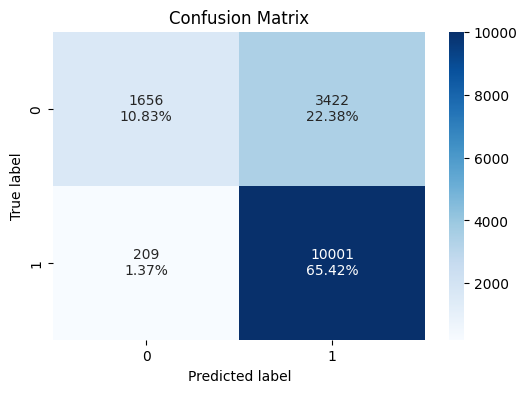

```python
confusion_matrix_sklearn(xgb_tuned, X_train, y_train)
```

```python
xgb_tuned_model_train_perf = model_performance_classification_sklearn(xgb_tuned, X_train, y_train)
xgb_tuned_model_train_perf
```

|  | Accuracy | Recall | Precision | F1 |
| --- | --- | --- | --- | --- |
| 0 | 0.762493 | 0.97953 | 0.745064 | 0.846359 |

### Checking model performance on validation set

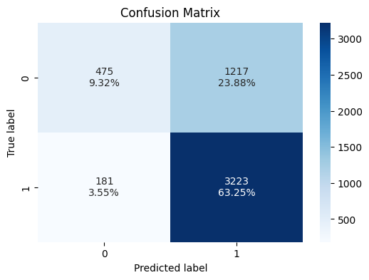

```python
confusion_matrix_sklearn(xgb_tuned, X_val, y_val)
```

```python
xgb_tuned_model_val_perf = model_performance_classification_sklearn(xgb_tuned, X_val, y_val)
xgb_tuned_model_val_perf
```

|  | Accuracy | Recall | Precision | F1 |
| --- | --- | --- | --- | --- |
| 0 | 0.725667 | 0.946827 | 0.725901 | 0.821775 |

#### Based on the tuned XGBoost Classifier's performance on both the training and validation sets, the following observations can be made:

##### F1 Score: The tuned XGBoost Classifier achieves an F1 score of 0.8464 on the training set and 0.8218 on the validation set, with a difference of 0.0246 between the two. While this gap is considerably smaller than that of the untuned model, it remains the largest overfitting margin among the three boosting-based models evaluated — indicating that hyperparameter tuning has improved but not fully resolved the model's tendency to overfit.

##### Recall: The model records exceptionally high recall scores of 0.9795 on the training set and 0.9468 on the validation set — the highest recall figures observed across all tuned models in this analysis. This confirms that the XGBoost Classifier is highly effective at capturing the vast majority of actual Certified visa applications, with very few true positives being missed on either set.

##### Precision: Precision scores of 0.7451 on the training set and 0.7259 on the validation set, while still acceptable, are the lowest among the three tuned boosting models. The notable gap between XGBoost's recall and precision scores suggests that the model's aggressive identification of Certified cases comes at the cost of a higher rate of false positives — meaning it is more likely than AdaBoost or Gradient Boosting to incorrectly predict a Denied application as Certified.

##### Overall: The tuned XGBoost Classifier demonstrates strong predictive power, particularly in its ability to identify Certified cases, as evidenced by its industry-leading recall scores. However, its comparatively lower precision and larger training-to-validation F1 gap position it slightly behind the tuned AdaBoost and Gradient Boosting models in terms of overall balance and generalization stability.